# Exercício: SARIMA no comércio varejista brasileiro

## Sobre o exercício

A base é a **PMC** (Pesquisa Mensal do Comércio) do IBGE: índice de volume de vendas no **comércio varejista ampliado** (inclui veículos e materiais de construção), por **Unidade da Federação**, mensal de jan/2004 em diante. Base 2022 = 100, **sem ajuste sazonal**.

## Setup

```python
import numpy as np
import pandas as pd
import matplotlib.pyplot as plt
import scipy.stats as st
from IPython.display import Markdown
from statsmodels.tsa.stattools import adfuller, kpss
from statsmodels.tsa.seasonal import STL
from statsmodels.stats.diagnostic import acorr_ljungbox
from statsmodels.graphics.tsaplots import plot_acf, plot_pacf
from statsforecast import StatsForecast
from statsforecast.models import AutoARIMA, ARIMA
from statsforecast.arima import ndiffs, nsdiffs, arima_string
import warnings; warnings.filterwarnings("ignore")
```

## Carregando a base PMC

A base já foi pré-processada, no formato “long”: coluna de data `data`, índice de volume `volume_idx` e UF em `uf`.

```python
pmc = pd.read_csv("https://github.com/padsInsper/202634-fa/releases/download/data/pmc_volume_uf.csv")
print(sorted(pmc["uf"].unique()))
```

[output not shown]

## Escolha sua UF

```python
MINHA_UF = "São Paulo"
if MINHA_UF not in set(pmc["uf"]):          # caso a base use sigla
    MINHA_UF = "SP"
assert MINHA_UF in set(pmc["uf"]), sorted(pmc["uf"].unique())

df_sf = (
    pmc.query("uf == @MINHA_UF")
    .rename(columns={"uf": "unique_id", "data": "ds", "volume_idx": "y"})
    [["unique_id", "ds", "y"]]
    .reset_index(drop=True)
)
df_sf["ds"] = pd.to_datetime(df_sf["ds"])
df_sf = df_sf.sort_values("ds").dropna()
serie = df_sf.set_index("ds")["y"].asfreq("MS")
y = serie.values.astype(float)
df_sf.head()
```

|  | unique_id | ds | y |
| --- | --- | --- | --- |
| 0 | São Paulo | 2004-01-01 | 52.53519 |
| 1 | São Paulo | 2004-02-01 | 50.98433 |
| 2 | São Paulo | 2004-03-01 | 57.18775 |
| 3 | São Paulo | 2004-04-01 | 54.76454 |
| 4 | São Paulo | 2004-05-01 | 57.09082 |

## Análise descritiva

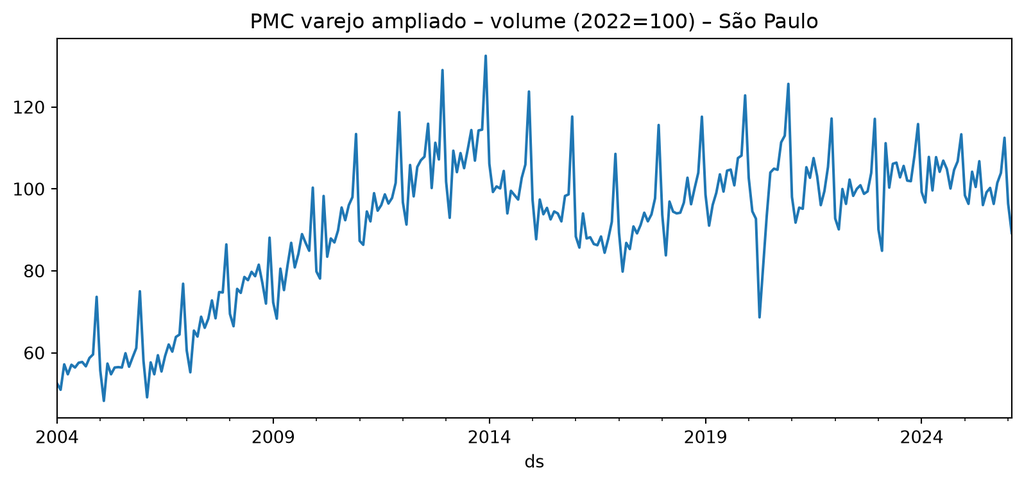

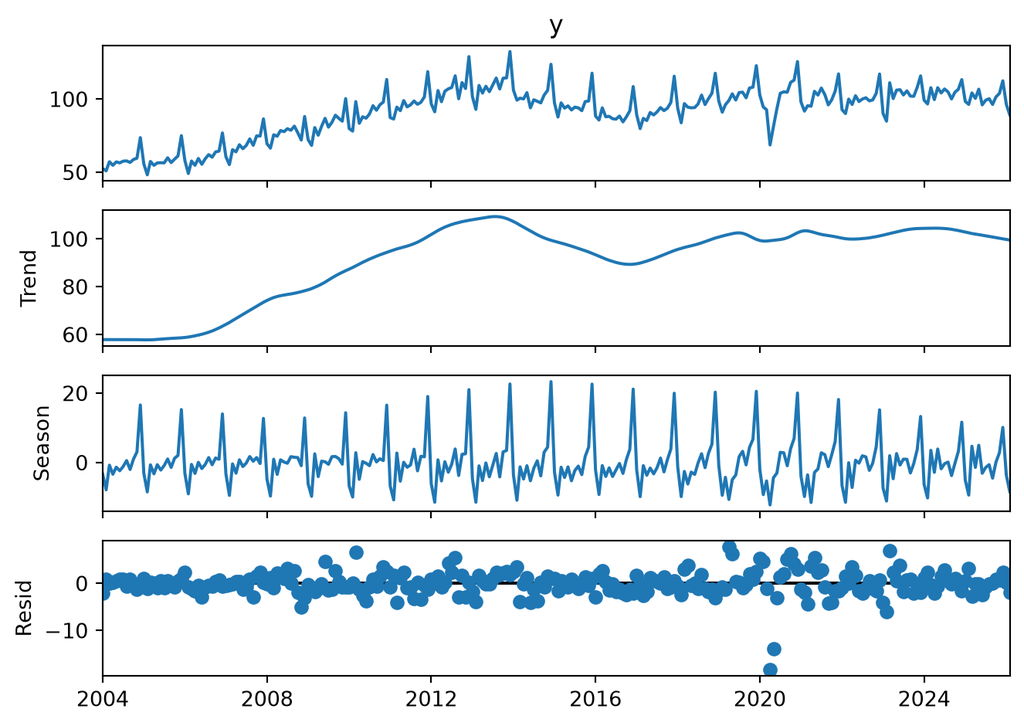

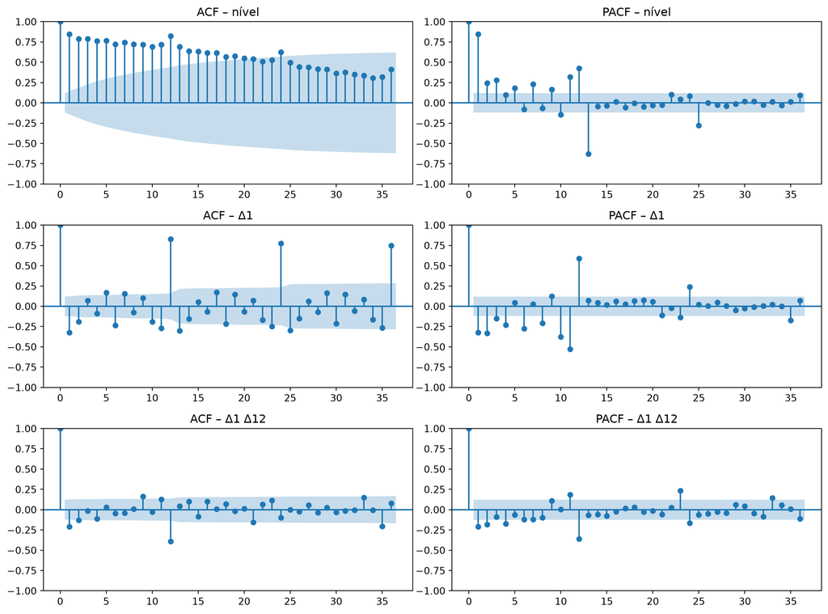

```python
fig, ax = plt.subplots(figsize=(10, 4))
serie.plot(ax=ax); ax.set_title(f"PMC varejo ampliado – volume (2022=100) – {MINHA_UF}")
plt.show()

STL(serie, period=12).fit().plot(); plt.show()

fig, axs = plt.subplots(3, 2, figsize=(12, 9))
for i, (nome, s) in enumerate([("nível", serie),
                               ("Δ1", serie.diff().dropna()),
                               ("Δ1 Δ12", serie.diff().diff(12).dropna())]):
    plot_acf(s, lags=36, ax=axs[i, 0], title=f"ACF – {nome}")
    plot_pacf(s, lags=36, ax=axs[i, 1], title=f"PACF – {nome}", method="ywm")
plt.tight_layout(); plt.show()
```

### Testes de raiz unitária e `ndiffs`

```python
def testes(s, nome):
    a = adfuller(s, autolag="AIC"); k = kpss(s, regression="c", nlags="auto")
    return {"série": nome, "ADF stat": a[0], "ADF p": a[1], "KPSS stat": k[0], "KPSS p": k[1]}

tab_testes = pd.DataFrame([testes(serie, "nível"),
                           testes(serie.diff().dropna(), "Δ1"),
                           testes(serie.diff().diff(12).dropna(), "Δ1 Δ12")]).round(4)
n_d, n_D = ndiffs(y), nsdiffs(y, period=12)
print(f"ndiffs = {n_d} | nsdiffs = {n_D}")
tab_testes
```

```
ndiffs = 1 | nsdiffs = 1
```

|  | série | ADF stat | ADF p | KPSS stat | KPSS p |
| --- | --- | --- | --- | --- | --- |
| 0 | nível | -2.1867 | 0.2111 | 1.6202 | 0.01 |
| 1 | Δ1 | -5.4528 | 0.0000 | 0.2710 | 0.10 |
| 2 | Δ1 Δ12 | -6.4478 | 0.0000 | 0.0550 | 0.10 |

ADF: H0 = raiz unitária. KPSS: H0 = estacionariedade.

## Modelagem

```python
modelo = AutoARIMA(season_length=12).fit(y)
p, q, P, Q, s, d, D = modelo.model_["arma"]
print(arima_string(modelo.model_))
print("AICc:", round(modelo.model_["aicc"], 2))
```

```
ARIMA(2,1,1)(0,1,1)[12]
AICc: 1446.54
```

### Diagnóstico dos resíduos

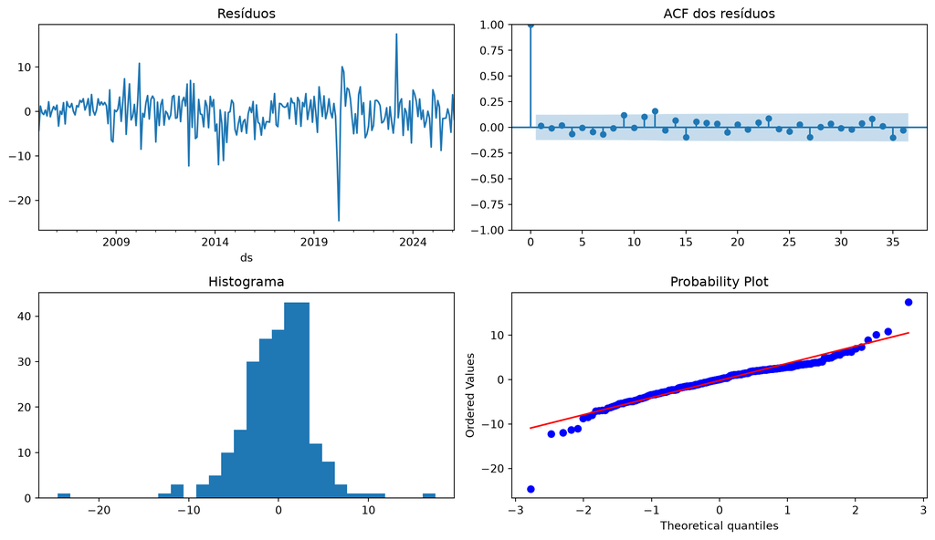

```
      lb_stat  lb_pvalue
12  15.991189   0.191640
24  25.391709   0.384732
Jarque-Bera p = 0.0
```

```python
res = pd.Series(np.asarray(modelo.model_["residuals"]), index=serie.index).iloc[13:]
fig, axs = plt.subplots(2, 2, figsize=(12, 7))
res.plot(ax=axs[0, 0], title="Resíduos")
plot_acf(res, lags=36, ax=axs[0, 1], title="ACF dos resíduos")
axs[1, 0].hist(res, bins=30); axs[1, 0].set_title("Histograma")
st.probplot(res, plot=axs[1, 1]); plt.tight_layout(); plt.show()

lb = acorr_ljungbox(res, lags=[12, 24], return_df=True)
jb_p = st.jarque_bera(res).pvalue
print(lb); print("Jarque-Bera p =", round(jb_p, 4))
```

## Previsão · 24 meses à frente

[figure not shown]

|  | mean | lo-95 | lo-80 | hi-80 | hi-95 |
| --- | --- | --- | --- | --- | --- |
| 2026-03-01 | 99.64 | NaN | NaN | NaN | NaN |
| 2026-04-01 | 94.09 | NaN | NaN | NaN | NaN |
| 2026-05-01 | 100.23 | NaN | NaN | NaN | NaN |
| 2026-06-01 | 97.71 | NaN | NaN | NaN | NaN |
| 2026-07-01 | 100.29 | NaN | NaN | NaN | NaN |
| 2026-08-01 | 101.35 | NaN | NaN | NaN | NaN |
| 2026-09-01 | 97.62 | NaN | NaN | NaN | NaN |
| 2026-10-01 | 101.34 | NaN | NaN | NaN | NaN |
| 2026-11-01 | 104.16 | NaN | NaN | NaN | NaN |
| 2026-12-01 | 116.40 | NaN | NaN | NaN | NaN |
| 2027-01-01 | 95.73 | NaN | NaN | NaN | NaN |
| 2027-02-01 | 90.35 | NaN | NaN | NaN | NaN |
| 2027-03-01 | 100.42 | NaN | NaN | NaN | NaN |
| 2027-04-01 | 94.70 | NaN | NaN | NaN | NaN |
| 2027-05-01 | 100.76 | NaN | NaN | NaN | NaN |
| 2027-06-01 | 98.20 | NaN | NaN | NaN | NaN |
| 2027-07-01 | 100.76 | NaN | NaN | NaN | NaN |
| 2027-08-01 | 101.81 | NaN | NaN | NaN | NaN |
| 2027-09-01 | 98.07 | NaN | NaN | NaN | NaN |
| 2027-10-01 | 101.79 | NaN | NaN | NaN | NaN |
| 2027-11-01 | 104.61 | NaN | NaN | NaN | NaN |
| 2027-12-01 | 116.85 | NaN | NaN | NaN | NaN |
| 2028-01-01 | 96.17 | NaN | NaN | NaN | NaN |
| 2028-02-01 | 90.79 | NaN | NaN | NaN | NaN |

```python
fc = modelo.predict(h=24, level=[80, 95])
idx = pd.date_range(serie.index[-1] + pd.offsets.MonthBegin(), periods=24, freq="MS")
prev = pd.DataFrame(fc, index=idx)

fig, ax = plt.subplots(figsize=(11, 4.5))
serie["2015":].plot(ax=ax, label="Observado")
ax.plot(prev.index, prev["mean"], label="Previsão")
ax.fill_between(prev.index, prev["lo-95"], prev["hi-95"], alpha=.2, label="IC 95%")
ax.fill_between(prev.index, prev["lo-80"], prev["hi-80"], alpha=.35, label="IC 80%")
ax.legend(); ax.set_title(f"SARIMA – previsão 24 meses – {MINHA_UF}"); plt.show()
prev.round(2)
```

## Discussão

Perguntas: (1) ACF/PACF sugeriu sazonalidade e tendência? (2) Quantas diferenças e quais componentes AR/MA? (3) Resíduos são white noise? (4) A previsão é razoável? (5) Que outras UFs dariam um SARIMA diferente?

```python
acf12 = pd.Series(serie.diff().dropna()).autocorr(12)
lb_p12, lb_p24 = lb["lb_pvalue"].iloc[0], lb["lb_pvalue"].iloc[1]
larg_ini = prev["hi-95"].iloc[0] - prev["lo-95"].iloc[0]
larg_fim = prev["hi-95"].iloc[-1] - prev["lo-95"].iloc[-1]
adf_p, kpss_p = tab_testes.loc[0, "ADF p"], tab_testes.loc[0, "KPSS p"]

txt = f"""
**1. Sazonalidade e tendência.** A ACF da série em nível decai lentamente, o que indica tendência/persistência. Há picos recorrentes nas defasagens 12, 24 e 36, sinal de sazonalidade anual (autocorrelação lag 12 da série diferenciada = {acf12:.2f}). Isso é coerente com o gráfico de linha, que mostra picos todo dezembro e um nível que varia ao longo dos ciclos (queda em 2015‑16, choque em 2020). Em nível, ADF p = {adf_p:.3f} e KPSS p = {kpss_p:.3f}.

**2. Ordem do modelo.** O AutoARIMA escolheu **SARIMA({p},{d},{q})({P},{D},{Q})[{s}]**, com {d} diferença(s) regular(es) e {D} sazonal(is) (`ndiffs` = {n_d}, `nsdiffs` = {n_D}). Os termos AR={p}, MA={q}, SAR={P}, SMA={Q} são compatíveis com a ACF/PACF da série Δ1Δ12: cortes nas primeiras defasagens indicam a parte regular, e o comportamento no lag 12 indica a parte sazonal.

**3. Resíduos.** Ljung‑Box p = {lb_p12:.3f} (lag 12) e {lb_p24:.3f} (lag 24): {"não rejeitamos ruído branco" if min(lb_p12, lb_p24) > 0.05 else "há autocorrelação remanescente, possivelmente sazonal"}. Jarque‑Bera p = {jb_p:.3f}: {"resíduos aproximadamente normais" if jb_p > 0.05 else "caudas pesadas, puxadas sobretudo pelos outliers de 2020"}.

**4. Previsão.** A projeção reproduz o padrão sazonal e fica ancorada no nível recente. A amplitude do IC 95% vai de {larg_ini:.1f} para {larg_fim:.1f} pontos ao longo dos 24 meses, alargamento esperado pela integração (d/D) do modelo.

**5. Outras UFs.** São Paulo tem um varejo grande e diversificado (indústria, serviços, renda alta e distribuída), o que gera uma série relativamente suave, com sazonalidade de dezembro bem definida. Estados do Centro‑Oeste ligados ao agro (MT, MS, GO) devem apresentar tendência de crescimento mais forte e ciclos atrelados à safra e aos preços de commodities, com peso maior de veículos e materiais de construção no varejo ampliado. Estados do Nordeste com turismo relevante (CE, RN, BA) tendem a ter picos adicionais nas férias de julho e no verão. Já UFs pequenas do Norte (RR, AP, AC) têm séries bem mais voláteis, o que leva a ordens AR/MA diferentes e intervalos de previsão mais largos.
"""
print(txt)
```

[output not shown]

**1. Sazonalidade e tendência.** A ACF da série em nível decai lentamente, o que indica tendência/persistência. Há picos recorrentes nas defasagens 12, 24 e 36, sinal de sazonalidade anual (autocorrelação lag 12 da série diferenciada = 0.85). Isso é coerente com o gráfico de linha, que mostra picos todo dezembro e um nível que varia ao longo dos ciclos (queda em 2015‑16, choque em 2020). Em nível, ADF p = 0.211 e KPSS p = 0.010.

**2. Ordem do modelo.** O AutoARIMA escolheu **SARIMA(2,1,1)(0,1,1)[12]**, com 1 diferença(s) regular(es) e 1 sazonal(is) (`ndiffs` = 1, `nsdiffs` = 1). Os termos AR=2, MA=1, SAR=0, SMA=1 são compatíveis com a ACF/PACF da série Δ1Δ12: cortes nas primeiras defasagens indicam a parte regular, e o comportamento no lag 12 indica a parte sazonal.

**3. Resíduos.** Ljung‑Box p = 0.192 (lag 12) e 0.385 (lag 24): não rejeitamos ruído branco. Jarque‑Bera p = 0.000: caudas pesadas, puxadas sobretudo pelos outliers de 2020.

**5. Outras UFs.** São Paulo tem um varejo grande e diversificado (indústria, serviços, renda alta e distribuída), o que gera uma série relativamente suave, com sazonalidade de dezembro bem definida. Estados do Centro‑Oeste ligados ao agro (MT, MS, GO) devem apresentar tendência de crescimento mais forte e ciclos atrelados à safra e aos preços de commodities, com peso maior de veículos e materiais de construção no varejo ampliado. Estados do Nordeste com turismo relevante (CE, RN, BA) tendem a ter picos adicionais nas férias de julho e no verão. Já UFs pequenas do Norte (RR, AP, AC) têm séries bem mais voláteis, o que leva a ordens AR/MA diferentes e intervalos de previsão mais largos.